# Risk Factor Analysis

## Outcome Variable

**Outcome Variable:** stunted

## Predictor Variables

**Intervention Variable:** lag_WHZ_quart

**Adjustment Set:**

- arm
- sex
- W_mage
- meducyrs
- feducyrs
- single
- month
- brthmon
- delta_W_mage
- delta_meducyrs
- delta_feducyrs
- delta_single
- delta_month
- delta_brthmon

## Stratifying Variables

The analysis was stratified on these variable(s):

- agecat
- studyid
- country

## Data Summary

| agecat | studyid | country | lag_WHZ_quart | stunted | n_cell | n |
| --- | --- | --- | --- | --- | --- | --- |
| 12 months | ki0047075b-MAL-ED | BANGLADESH | 1 | 0 | 12 | 230 |
| 12 months | ki0047075b-MAL-ED | BANGLADESH | 1 | 1 | 14 | 230 |
| 12 months | ki0047075b-MAL-ED | BANGLADESH | 2 | 0 | 56 | 230 |
| 12 months | ki0047075b-MAL-ED | BANGLADESH | 2 | 1 | 35 | 230 |
| 12 months | ki0047075b-MAL-ED | BANGLADESH | 3 | 0 | 63 | 230 |
| 12 months | ki0047075b-MAL-ED | BANGLADESH | 3 | 1 | 26 | 230 |
| 12 months | ki0047075b-MAL-ED | BANGLADESH | 4 | 0 | 21 | 230 |
| 12 months | ki0047075b-MAL-ED | BANGLADESH | 4 | 1 | 3 | 230 |
| 12 months | ki0047075b-MAL-ED | BRAZIL | 1 | 0 | 24 | 194 |
| 12 months | ki0047075b-MAL-ED | BRAZIL | 1 | 1 | 1 | 194 |
| 12 months | ki0047075b-MAL-ED | BRAZIL | 2 | 0 | 59 | 194 |
| 12 months | ki0047075b-MAL-ED | BRAZIL | 2 | 1 | 3 | 194 |
| 12 months | ki0047075b-MAL-ED | BRAZIL | 3 | 0 | 75 | 194 |
| 12 months | ki0047075b-MAL-ED | BRAZIL | 3 | 1 | 3 | 194 |
| 12 months | ki0047075b-MAL-ED | BRAZIL | 4 | 0 | 28 | 194 |
| 12 months | ki0047075b-MAL-ED | BRAZIL | 4 | 1 | 1 | 194 |
| 12 months | ki0047075b-MAL-ED | INDIA | 1 | 0 | 85 | 228 |
| 12 months | ki0047075b-MAL-ED | INDIA | 1 | 1 | 50 | 228 |
| 12 months | ki0047075b-MAL-ED | INDIA | 2 | 0 | 51 | 228 |
| 12 months | ki0047075b-MAL-ED | INDIA | 2 | 1 | 16 | 228 |
| 12 months | ki0047075b-MAL-ED | INDIA | 3 | 0 | 15 | 228 |
| 12 months | ki0047075b-MAL-ED | INDIA | 3 | 1 | 5 | 228 |
| 12 months | ki0047075b-MAL-ED | INDIA | 4 | 0 | 5 | 228 |
| 12 months | ki0047075b-MAL-ED | INDIA | 4 | 1 | 1 | 228 |
| 12 months | ki0047075b-MAL-ED | NEPAL | 1 | 0 | 62 | 231 |
| 12 months | ki0047075b-MAL-ED | NEPAL | 1 | 1 | 8 | 231 |
| 12 months | ki0047075b-MAL-ED | NEPAL | 2 | 0 | 81 | 231 |
| 12 months | ki0047075b-MAL-ED | NEPAL | 2 | 1 | 11 | 231 |
| 12 months | ki0047075b-MAL-ED | NEPAL | 3 | 0 | 54 | 231 |
| 12 months | ki0047075b-MAL-ED | NEPAL | 3 | 1 | 4 | 231 |

[output cut: 618 more lines]

The following strata were considered:

- agecat: 12 months, studyid: ki0047075b-MAL-ED, country: BANGLADESH
- agecat: 12 months, studyid: ki0047075b-MAL-ED, country: BRAZIL
- agecat: 12 months, studyid: ki0047075b-MAL-ED, country: INDIA
- agecat: 12 months, studyid: ki0047075b-MAL-ED, country: NEPAL
- agecat: 12 months, studyid: ki0047075b-MAL-ED, country: PERU
- agecat: 12 months, studyid: ki0047075b-MAL-ED, country: SOUTH AFRICA
- agecat: 12 months, studyid: ki0047075b-MAL-ED, country: TANZANIA, UNITED REPUBLIC OF
- agecat: 12 months, studyid: ki1000108-CMC-V-BCS-2002, country: INDIA
- agecat: 12 months, studyid: ki1000108-IRC, country: INDIA
- agecat: 12 months, studyid: ki1000109-EE, country: PAKISTAN
- agecat: 12 months, studyid: ki1017093b-PROVIDE, country: BANGLADESH
- agecat: 12 months, studyid: ki1066203-TanzaniaChild2, country: TANZANIA, UNITED REPUBLIC OF
- agecat: 12 months, studyid: ki1101329-Keneba, country: GAMBIA
- agecat: 12 months, studyid: ki1112895-Guatemala BSC, country: GUATEMALA
- agecat: 12 months, studyid: ki1113344-GMS-Nepal, country: NEPAL
- agecat: 12 months, studyid: ki1114097-CMIN, country: BANGLADESH
- agecat: 12 months, studyid: ki1114097-CMIN, country: PERU
- agecat: 18 months, studyid: ki0047075b-MAL-ED, country: BANGLADESH
- agecat: 18 months, studyid: ki0047075b-MAL-ED, country: BRAZIL
- agecat: 18 months, studyid: ki0047075b-MAL-ED, country: INDIA
- agecat: 18 months, studyid: ki0047075b-MAL-ED, country: NEPAL
- agecat: 18 months, studyid: ki0047075b-MAL-ED, country: PERU
- agecat: 18 months, studyid: ki0047075b-MAL-ED, country: SOUTH AFRICA
- agecat: 18 months, studyid: ki0047075b-MAL-ED, country: TANZANIA, UNITED REPUBLIC OF
- agecat: 18 months, studyid: ki1000108-CMC-V-BCS-2002, country: INDIA
- agecat: 18 months, studyid: ki1000108-IRC, country: INDIA
- agecat: 18 months, studyid: ki1000109-EE, country: PAKISTAN
- agecat: 18 months, studyid: ki1017093b-PROVIDE, country: BANGLADESH
- agecat: 18 months, studyid: ki1066203-TanzaniaChild2, country: TANZANIA, UNITED REPUBLIC OF
- agecat: 18 months, studyid: ki1101329-Keneba, country: GAMBIA
- agecat: 18 months, studyid: ki1113344-GMS-Nepal, country: NEPAL
- agecat: 18 months, studyid: ki1114097-CMIN, country: BANGLADESH
- agecat: 18 months, studyid: ki1114097-CMIN, country: PERU
- agecat: 3 months, studyid: ki0047075b-MAL-ED, country: BANGLADESH
- agecat: 3 months, studyid: ki0047075b-MAL-ED, country: BRAZIL
- agecat: 3 months, studyid: ki0047075b-MAL-ED, country: INDIA
- agecat: 3 months, studyid: ki0047075b-MAL-ED, country: NEPAL
- agecat: 3 months, studyid: ki0047075b-MAL-ED, country: PERU
- agecat: 3 months, studyid: ki0047075b-MAL-ED, country: SOUTH AFRICA
- agecat: 3 months, studyid: ki0047075b-MAL-ED, country: TANZANIA, UNITED REPUBLIC OF
- agecat: 3 months, studyid: ki1000108-CMC-V-BCS-2002, country: INDIA
- agecat: 3 months, studyid: ki1000108-IRC, country: INDIA
- agecat: 3 months, studyid: ki1000109-EE, country: PAKISTAN
- agecat: 3 months, studyid: ki1017093b-PROVIDE, country: BANGLADESH
- agecat: 3 months, studyid: ki1066203-TanzaniaChild2, country: TANZANIA, UNITED REPUBLIC OF
- agecat: 3 months, studyid: ki1101329-Keneba, country: GAMBIA
- agecat: 3 months, studyid: ki1114097-CMIN, country: BANGLADESH
- agecat: 3 months, studyid: ki1114097-CMIN, country: PERU
- agecat: 6 months, studyid: ki0047075b-MAL-ED, country: BANGLADESH
- agecat: 6 months, studyid: ki0047075b-MAL-ED, country: BRAZIL
- agecat: 6 months, studyid: ki0047075b-MAL-ED, country: INDIA
- agecat: 6 months, studyid: ki0047075b-MAL-ED, country: NEPAL
- agecat: 6 months, studyid: ki0047075b-MAL-ED, country: PERU
- agecat: 6 months, studyid: ki0047075b-MAL-ED, country: SOUTH AFRICA
- agecat: 6 months, studyid: ki0047075b-MAL-ED, country: TANZANIA, UNITED REPUBLIC OF
- agecat: 6 months, studyid: ki1000108-CMC-V-BCS-2002, country: INDIA
- agecat: 6 months, studyid: ki1000108-IRC, country: INDIA
- agecat: 6 months, studyid: ki1000109-EE, country: PAKISTAN
- agecat: 6 months, studyid: ki1017093b-PROVIDE, country: BANGLADESH
- agecat: 6 months, studyid: ki1066203-TanzaniaChild2, country: TANZANIA, UNITED REPUBLIC OF
- agecat: 6 months, studyid: ki1101329-Keneba, country: GAMBIA
- agecat: 6 months, studyid: ki1112895-Guatemala BSC, country: GUATEMALA
- agecat: 6 months, studyid: ki1114097-CMIN, country: BANGLADESH
- agecat: 6 months, studyid: ki1114097-CMIN, country: PERU
- agecat: 9 months, studyid: ki0047075b-MAL-ED, country: BANGLADESH
- agecat: 9 months, studyid: ki0047075b-MAL-ED, country: BRAZIL
- agecat: 9 months, studyid: ki0047075b-MAL-ED, country: INDIA
- agecat: 9 months, studyid: ki0047075b-MAL-ED, country: NEPAL
- agecat: 9 months, studyid: ki0047075b-MAL-ED, country: PERU
- agecat: 9 months, studyid: ki0047075b-MAL-ED, country: SOUTH AFRICA
- agecat: 9 months, studyid: ki0047075b-MAL-ED, country: TANZANIA, UNITED REPUBLIC OF
- agecat: 9 months, studyid: ki1000108-CMC-V-BCS-2002, country: INDIA
- agecat: 9 months, studyid: ki1000108-IRC, country: INDIA
- agecat: 9 months, studyid: ki1000109-EE, country: PAKISTAN
- agecat: 9 months, studyid: ki1017093b-PROVIDE, country: BANGLADESH
- agecat: 9 months, studyid: ki1066203-TanzaniaChild2, country: TANZANIA, UNITED REPUBLIC OF
- agecat: 9 months, studyid: ki1101329-Keneba, country: GAMBIA
- agecat: 9 months, studyid: ki1112895-Guatemala BSC, country: GUATEMALA
- agecat: 9 months, studyid: ki1113344-GMS-Nepal, country: NEPAL
- agecat: 9 months, studyid: ki1114097-CMIN, country: BANGLADESH
- agecat: 9 months, studyid: ki1114097-CMIN, country: PERU

### Dropped Strata

Some strata were dropped due to rare outcomes:

- agecat: 12 months, studyid: ki0047075b-MAL-ED, country: BANGLADESH
- agecat: 12 months, studyid: ki0047075b-MAL-ED, country: BRAZIL
- agecat: 12 months, studyid: ki0047075b-MAL-ED, country: INDIA
- agecat: 12 months, studyid: ki0047075b-MAL-ED, country: NEPAL
- agecat: 12 months, studyid: ki1000108-CMC-V-BCS-2002, country: INDIA
- agecat: 12 months, studyid: ki1000108-IRC, country: INDIA
- agecat: 12 months, studyid: ki1000109-EE, country: PAKISTAN
- agecat: 12 months, studyid: ki1113344-GMS-Nepal, country: NEPAL
- agecat: 18 months, studyid: ki0047075b-MAL-ED, country: BANGLADESH
- agecat: 18 months, studyid: ki0047075b-MAL-ED, country: BRAZIL
- agecat: 18 months, studyid: ki0047075b-MAL-ED, country: INDIA
- agecat: 18 months, studyid: ki0047075b-MAL-ED, country: NEPAL
- agecat: 18 months, studyid: ki0047075b-MAL-ED, country: TANZANIA, UNITED REPUBLIC OF
- agecat: 18 months, studyid: ki1000108-CMC-V-BCS-2002, country: INDIA
- agecat: 18 months, studyid: ki1000108-IRC, country: INDIA
- agecat: 18 months, studyid: ki1000109-EE, country: PAKISTAN
- agecat: 18 months, studyid: ki1113344-GMS-Nepal, country: NEPAL
- agecat: 18 months, studyid: ki1114097-CMIN, country: PERU
- agecat: 3 months, studyid: ki0047075b-MAL-ED, country: BANGLADESH
- agecat: 3 months, studyid: ki0047075b-MAL-ED, country: BRAZIL
- agecat: 3 months, studyid: ki0047075b-MAL-ED, country: INDIA
- agecat: 3 months, studyid: ki0047075b-MAL-ED, country: NEPAL
- agecat: 3 months, studyid: ki0047075b-MAL-ED, country: SOUTH AFRICA
- agecat: 3 months, studyid: ki0047075b-MAL-ED, country: TANZANIA, UNITED REPUBLIC OF
- agecat: 3 months, studyid: ki1000108-CMC-V-BCS-2002, country: INDIA
- agecat: 3 months, studyid: ki1000108-IRC, country: INDIA
- agecat: 3 months, studyid: ki1000109-EE, country: PAKISTAN
- agecat: 6 months, studyid: ki0047075b-MAL-ED, country: BANGLADESH
- agecat: 6 months, studyid: ki0047075b-MAL-ED, country: BRAZIL
- agecat: 6 months, studyid: ki0047075b-MAL-ED, country: INDIA
- agecat: 6 months, studyid: ki0047075b-MAL-ED, country: NEPAL
- agecat: 6 months, studyid: ki1000108-CMC-V-BCS-2002, country: INDIA
- agecat: 6 months, studyid: ki1000108-IRC, country: INDIA
- agecat: 6 months, studyid: ki1000109-EE, country: PAKISTAN
- agecat: 6 months, studyid: ki1017093b-PROVIDE, country: BANGLADESH
- agecat: 6 months, studyid: ki1114097-CMIN, country: PERU
- agecat: 9 months, studyid: ki0047075b-MAL-ED, country: BANGLADESH
- agecat: 9 months, studyid: ki0047075b-MAL-ED, country: BRAZIL
- agecat: 9 months, studyid: ki0047075b-MAL-ED, country: INDIA
- agecat: 9 months, studyid: ki0047075b-MAL-ED, country: NEPAL
- agecat: 9 months, studyid: ki1000108-CMC-V-BCS-2002, country: INDIA
- agecat: 9 months, studyid: ki1000108-IRC, country: INDIA
- agecat: 9 months, studyid: ki1000109-EE, country: PAKISTAN
- agecat: 9 months, studyid: ki1113344-GMS-Nepal, country: NEPAL

## Methods Detail

We’re interested in the causal parameters $E[Y_a]$ for all values of $a \in \mathcal{A}$. These parameters represent the mean outcome if, possibly contrary to fact, we intervened to set all units to have $A=a$. Under the randomization and positivity assumptions, these are identified by the statistical parameters $\psi_a=E_W[E_{Y|A,W}(Y|A=a,W)]$. In addition, we’re interested in the mean of $Y$, $E[Y]$ under no intervention (the observed mean). We will estimate these parameters by using SuperLearner to fit the relevant likelihood factors – $E_{Y|A,W}(Y|A=a,W)$ and $p(A=a|W)$, and then updating our likelihood fit using a joint TMLE.

For unadjusted analyses ($W=\{\}$), initial likelihoods were estimated using Lrnr_glm to estimate the simple $E(Y|A)$ and Lrnr_mean to estimate $p(A)$. For adjusted analyses, a small library containing Lrnr_glmnet, Lrnr_xgboost, and Lrnr_mean was used.

Having estimated these parameters, we will then use the delta method to estimate relative risks and attributable risks relative to a prespecified baseline level of $A$.

# Results Detail

## Results Plots

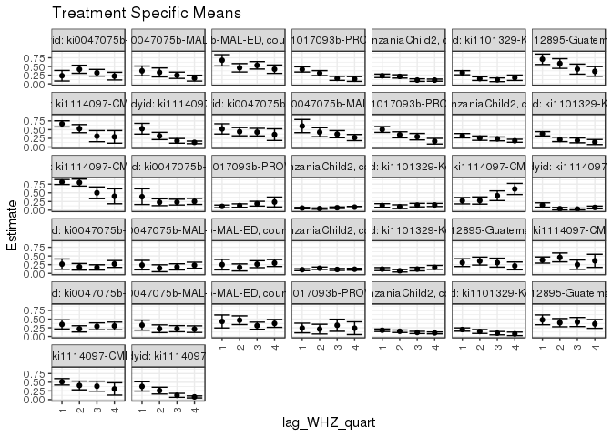

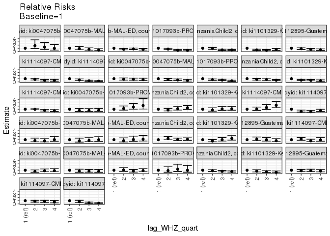

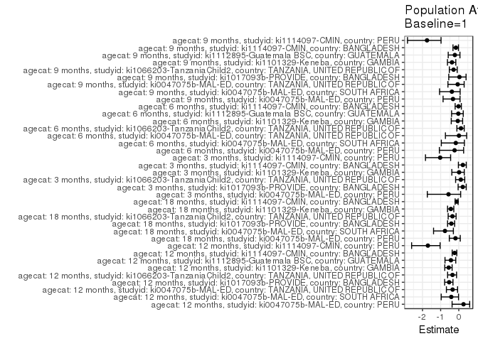

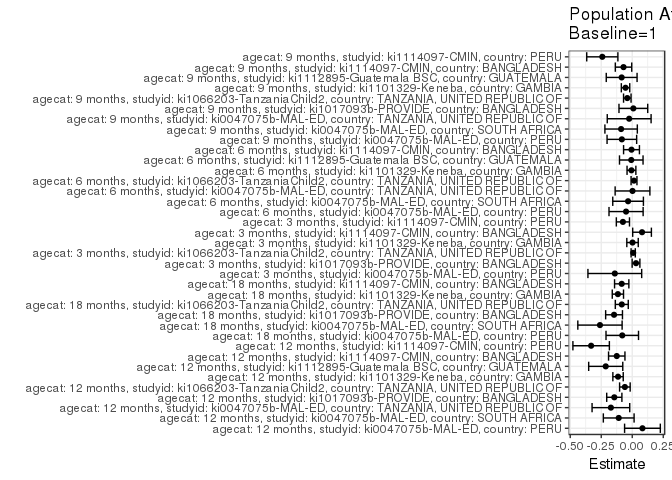

## Results Table

### Parameter: TSM

| agecat | studyid | country | intervention_level | baseline_level | estimate | ci_lower | ci_upper |
| --- | --- | --- | --- | --- | --- | --- | --- |
| 12 months | ki0047075b-MAL-ED | PERU | 1 | NA | 0.2333333 | 0.0816734 | 0.3849933 |
| 12 months | ki0047075b-MAL-ED | PERU | 2 | NA | 0.4202899 | 0.3035833 | 0.5369964 |
| 12 months | ki0047075b-MAL-ED | PERU | 3 | NA | 0.3186813 | 0.2227473 | 0.4146153 |
| 12 months | ki0047075b-MAL-ED | PERU | 4 | NA | 0.2222222 | 0.1111093 | 0.3333351 |
| 12 months | ki0047075b-MAL-ED | SOUTH AFRICA | 1 | NA | 0.3731856 | 0.2330173 | 0.5133540 |
| 12 months | ki0047075b-MAL-ED | SOUTH AFRICA | 2 | NA | 0.3292134 | 0.2009769 | 0.4574500 |
| 12 months | ki0047075b-MAL-ED | SOUTH AFRICA | 3 | NA | 0.2471228 | 0.1562079 | 0.3380376 |
| 12 months | ki0047075b-MAL-ED | SOUTH AFRICA | 4 | NA | 0.1633561 | 0.0790223 | 0.2476899 |
| 12 months | ki0047075b-MAL-ED | TANZANIA, UNITED REPUBLIC OF | 1 | NA | 0.6787070 | 0.5172189 | 0.8401950 |
| 12 months | ki0047075b-MAL-ED | TANZANIA, UNITED REPUBLIC OF | 2 | NA | 0.4620288 | 0.3410222 | 0.5830355 |
| 12 months | ki0047075b-MAL-ED | TANZANIA, UNITED REPUBLIC OF | 3 | NA | 0.5325934 | 0.4258937 | 0.6392930 |
| 12 months | ki0047075b-MAL-ED | TANZANIA, UNITED REPUBLIC OF | 4 | NA | 0.4219497 | 0.3011002 | 0.5427992 |
| 12 months | ki1017093b-PROVIDE | BANGLADESH | 1 | NA | 0.4161520 | 0.3406625 | 0.4916414 |
| 12 months | ki1017093b-PROVIDE | BANGLADESH | 2 | NA | 0.3091612 | 0.2378771 | 0.3804454 |
| 12 months | ki1017093b-PROVIDE | BANGLADESH | 3 | NA | 0.1574541 | 0.0982728 | 0.2166353 |
| 12 months | ki1017093b-PROVIDE | BANGLADESH | 4 | NA | 0.1398891 | 0.0715291 | 0.2082490 |
| 12 months | ki1066203-TanzaniaChild2 | TANZANIA, UNITED REPUBLIC OF | 1 | NA | 0.2309356 | 0.1808433 | 0.2810279 |
| 12 months | ki1066203-TanzaniaChild2 | TANZANIA, UNITED REPUBLIC OF | 2 | NA | 0.2138967 | 0.1658080 | 0.2619854 |
| 12 months | ki1066203-TanzaniaChild2 | TANZANIA, UNITED REPUBLIC OF | 3 | NA | 0.1082474 | 0.0719084 | 0.1445864 |
| 12 months | ki1066203-TanzaniaChild2 | TANZANIA, UNITED REPUBLIC OF | 4 | NA | 0.1064004 | 0.0767056 | 0.1360952 |
| 12 months | ki1101329-Keneba | GAMBIA | 1 | NA | 0.3201345 | 0.2616186 | 0.3786503 |
| 12 months | ki1101329-Keneba | GAMBIA | 2 | NA | 0.1502457 | 0.0965586 | 0.2039328 |
| 12 months | ki1101329-Keneba | GAMBIA | 3 | NA | 0.1171955 | 0.0642334 | 0.1701575 |
| 12 months | ki1101329-Keneba | GAMBIA | 4 | NA | 0.1757240 | 0.0972964 | 0.2541516 |
| 12 months | ki1112895-Guatemala BSC | GUATEMALA | 1 | NA | 0.7074167 | 0.5569935 | 0.8578399 |
| 12 months | ki1112895-Guatemala BSC | GUATEMALA | 2 | NA | 0.5847258 | 0.4464949 | 0.7229567 |
| 12 months | ki1112895-Guatemala BSC | GUATEMALA | 3 | NA | 0.4249983 | 0.2806461 | 0.5693504 |
| 12 months | ki1112895-Guatemala BSC | GUATEMALA | 4 | NA | 0.3582492 | 0.2189319 | 0.4975665 |
| 12 months | ki1114097-CMIN | BANGLADESH | 1 | NA | 0.6666667 | 0.5799513 | 0.7533820 |
| 12 months | ki1114097-CMIN | BANGLADESH | 2 | NA | 0.5285714 | 0.4113882 | 0.6457547 |

[output cut: 118 more lines]

### Parameter: E(Y)

| agecat | studyid | country | intervention_level | baseline_level | estimate | ci_lower | ci_upper |
| --- | --- | --- | --- | --- | --- | --- | --- |
| 12 months | ki0047075b-MAL-ED | PERU | NA | NA | 0.3155738 | 0.2571407 | 0.3740068 |
| 12 months | ki0047075b-MAL-ED | SOUTH AFRICA | NA | NA | 0.2640000 | 0.2092493 | 0.3187507 |
| 12 months | ki0047075b-MAL-ED | TANZANIA, UNITED REPUBLIC OF | NA | NA | 0.5064935 | 0.4418809 | 0.5711062 |
| 12 months | ki1017093b-PROVIDE | BANGLADESH | NA | NA | 0.2714026 | 0.2341712 | 0.3086339 |
| 12 months | ki1066203-TanzaniaChild2 | TANZANIA, UNITED REPUBLIC OF | NA | NA | 0.1714507 | 0.1508672 | 0.1920342 |
| 12 months | ki1101329-Keneba | GAMBIA | NA | NA | 0.2055921 | 0.1734423 | 0.2377419 |
| 12 months | ki1112895-Guatemala BSC | GUATEMALA | NA | NA | 0.4935065 | 0.4142863 | 0.5727267 |
| 12 months | ki1114097-CMIN | BANGLADESH | NA | NA | 0.5416667 | 0.4784974 | 0.6048359 |
| 12 months | ki1114097-CMIN | PERU | NA | NA | 0.1946429 | 0.1618216 | 0.2274641 |
| 18 months | ki0047075b-MAL-ED | PERU | NA | NA | 0.4403670 | 0.3743163 | 0.5064176 |
| 18 months | ki0047075b-MAL-ED | SOUTH AFRICA | NA | NA | 0.3416667 | 0.2815391 | 0.4017942 |
| 18 months | ki1017093b-PROVIDE | BANGLADESH | NA | NA | 0.3574879 | 0.3112664 | 0.4037095 |
| 18 months | ki1066203-TanzaniaChild2 | TANZANIA, UNITED REPUBLIC OF | NA | NA | 0.2409357 | 0.2122537 | 0.2696176 |
| 18 months | ki1101329-Keneba | GAMBIA | NA | NA | 0.2651391 | 0.2301105 | 0.3001677 |
| 18 months | ki1114097-CMIN | BANGLADESH | NA | NA | 0.7253219 | 0.6678862 | 0.7827575 |
| 3 months | ki0047075b-MAL-ED | PERU | NA | NA | 0.2482270 | 0.1977186 | 0.2987353 |
| 3 months | ki1017093b-PROVIDE | BANGLADESH | NA | NA | 0.1396934 | 0.1116252 | 0.1677615 |
| 3 months | ki1066203-TanzaniaChild2 | TANZANIA, UNITED REPUBLIC OF | NA | NA | 0.0682949 | 0.0577780 | 0.0788117 |
| 3 months | ki1101329-Keneba | GAMBIA | NA | NA | 0.1371994 | 0.1118203 | 0.1625786 |
| 3 months | ki1114097-CMIN | BANGLADESH | NA | NA | 0.3508065 | 0.2912923 | 0.4103206 |
| 3 months | ki1114097-CMIN | PERU | NA | NA | 0.0733788 | 0.0522485 | 0.0945092 |
| 6 months | ki0047075b-MAL-ED | PERU | NA | NA | 0.2148148 | 0.1657364 | 0.2638932 |
| 6 months | ki0047075b-MAL-ED | SOUTH AFRICA | NA | NA | 0.2031873 | 0.1533098 | 0.2530647 |
| 6 months | ki0047075b-MAL-ED | TANZANIA, UNITED REPUBLIC OF | NA | NA | 0.2520661 | 0.1972475 | 0.3068848 |
| 6 months | ki1066203-TanzaniaChild2 | TANZANIA, UNITED REPUBLIC OF | NA | NA | 0.1184834 | 0.1039441 | 0.1330227 |
| 6 months | ki1101329-Keneba | GAMBIA | NA | NA | 0.1149733 | 0.0920981 | 0.1378484 |
| 6 months | ki1112895-Guatemala BSC | GUATEMALA | NA | NA | 0.3004292 | 0.2414375 | 0.3594209 |
| 6 months | ki1114097-CMIN | BANGLADESH | NA | NA | 0.3765690 | 0.3150122 | 0.4381258 |
| 9 months | ki0047075b-MAL-ED | PERU | NA | NA | 0.2629482 | 0.2083772 | 0.3175192 |
| 9 months | ki0047075b-MAL-ED | SOUTH AFRICA | NA | NA | 0.2360000 | 0.1832587 | 0.2887413 |
| 9 months | ki0047075b-MAL-ED | TANZANIA, UNITED REPUBLIC OF | NA | NA | 0.4067797 | 0.3439736 | 0.4695858 |
| 9 months | ki1017093b-PROVIDE | BANGLADESH | NA | NA | 0.2521008 | 0.1737550 | 0.3304466 |
| 9 months | ki1066203-TanzaniaChild2 | TANZANIA, UNITED REPUBLIC OF | NA | NA | 0.1389728 | 0.1223021 | 0.1556435 |
| 9 months | ki1101329-Keneba | GAMBIA | NA | NA | 0.1443299 | 0.1178775 | 0.1707823 |
| 9 months | ki1112895-Guatemala BSC | GUATEMALA | NA | NA | 0.3932584 | 0.3212966 | 0.4652203 |
| 9 months | ki1114097-CMIN | BANGLADESH | NA | NA | 0.4426230 | 0.3801724 | 0.5050735 |
| 9 months | ki1114097-CMIN | PERU | NA | NA | 0.1378709 | 0.1096173 | 0.1661244 |

### Parameter: RR

| agecat | studyid | country | intervention_level | baseline_level | estimate | ci_lower | ci_upper |
| --- | --- | --- | --- | --- | --- | --- | --- |
| 12 months | ki0047075b-MAL-ED | PERU | 1 | 1 | 1.0000000 | 1.0000000 | 1.0000000 |
| 12 months | ki0047075b-MAL-ED | PERU | 2 | 1 | 1.8012422 | 0.8884067 | 3.6520140 |
| 12 months | ki0047075b-MAL-ED | PERU | 3 | 1 | 1.3657771 | 0.6672600 | 2.7955324 |
| 12 months | ki0047075b-MAL-ED | PERU | 4 | 1 | 0.9523810 | 0.4194406 | 2.1624740 |
| 12 months | ki0047075b-MAL-ED | SOUTH AFRICA | 1 | 1 | 1.0000000 | 1.0000000 | 1.0000000 |
| 12 months | ki0047075b-MAL-ED | SOUTH AFRICA | 2 | 1 | 0.8821707 | 0.5150638 | 1.5109296 |
| 12 months | ki0047075b-MAL-ED | SOUTH AFRICA | 3 | 1 | 0.6621979 | 0.3919375 | 1.1188165 |
| 12 months | ki0047075b-MAL-ED | SOUTH AFRICA | 4 | 1 | 0.4377341 | 0.2319176 | 0.8262033 |
| 12 months | ki0047075b-MAL-ED | TANZANIA, UNITED REPUBLIC OF | 1 | 1 | 1.0000000 | 1.0000000 | 1.0000000 |
| 12 months | ki0047075b-MAL-ED | TANZANIA, UNITED REPUBLIC OF | 2 | 1 | 0.6807486 | 0.4777964 | 0.9699082 |
| 12 months | ki0047075b-MAL-ED | TANZANIA, UNITED REPUBLIC OF | 3 | 1 | 0.7847177 | 0.5757767 | 1.0694803 |
| 12 months | ki0047075b-MAL-ED | TANZANIA, UNITED REPUBLIC OF | 4 | 1 | 0.6216964 | 0.4279171 | 0.9032274 |
| 12 months | ki1017093b-PROVIDE | BANGLADESH | 1 | 1 | 1.0000000 | 1.0000000 | 1.0000000 |
| 12 months | ki1017093b-PROVIDE | BANGLADESH | 2 | 1 | 0.7429047 | 0.5546311 | 0.9950892 |
| 12 months | ki1017093b-PROVIDE | BANGLADESH | 3 | 1 | 0.3783571 | 0.2492493 | 0.5743412 |
| 12 months | ki1017093b-PROVIDE | BANGLADESH | 4 | 1 | 0.3361490 | 0.1997169 | 0.5657817 |
| 12 months | ki1066203-TanzaniaChild2 | TANZANIA, UNITED REPUBLIC OF | 1 | 1 | 1.0000000 | 1.0000000 | 1.0000000 |
| 12 months | ki1066203-TanzaniaChild2 | TANZANIA, UNITED REPUBLIC OF | 2 | 1 | 0.9262180 | 0.6773752 | 1.2664765 |
| 12 months | ki1066203-TanzaniaChild2 | TANZANIA, UNITED REPUBLIC OF | 3 | 1 | 0.4687342 | 0.3143487 | 0.6989426 |
| 12 months | ki1066203-TanzaniaChild2 | TANZANIA, UNITED REPUBLIC OF | 4 | 1 | 0.4607363 | 0.3234989 | 0.6561937 |
| 12 months | ki1101329-Keneba | GAMBIA | 1 | 1 | 1.0000000 | 1.0000000 | 1.0000000 |
| 12 months | ki1101329-Keneba | GAMBIA | 2 | 1 | 0.4693206 | 0.3142737 | 0.7008598 |
| 12 months | ki1101329-Keneba | GAMBIA | 3 | 1 | 0.3660820 | 0.2248853 | 0.5959306 |
| 12 months | ki1101329-Keneba | GAMBIA | 4 | 1 | 0.5489068 | 0.3387853 | 0.8893500 |
| 12 months | ki1112895-Guatemala BSC | GUATEMALA | 1 | 1 | 1.0000000 | 1.0000000 | 1.0000000 |
| 12 months | ki1112895-Guatemala BSC | GUATEMALA | 2 | 1 | 0.8265649 | 0.6028002 | 1.1333930 |
| 12 months | ki1112895-Guatemala BSC | GUATEMALA | 3 | 1 | 0.6007750 | 0.4027670 | 0.8961277 |
| 12 months | ki1112895-Guatemala BSC | GUATEMALA | 4 | 1 | 0.5064189 | 0.3251263 | 0.7888015 |
| 12 months | ki1114097-CMIN | BANGLADESH | 1 | 1 | 1.0000000 | 1.0000000 | 1.0000000 |
| 12 months | ki1114097-CMIN | BANGLADESH | 2 | 1 | 0.7928571 | 0.6131466 | 1.0252400 |

[output cut: 118 more lines]

### Parameter: PAR

| agecat | studyid | country | intervention_level | baseline_level | estimate | ci_lower | ci_upper |
| --- | --- | --- | --- | --- | --- | --- | --- |
| 12 months | ki0047075b-MAL-ED | PERU | 1 | NA | 0.0822404 | -0.0618403 | 0.2263211 |
| 12 months | ki0047075b-MAL-ED | SOUTH AFRICA | 1 | NA | -0.1091856 | -0.2331636 | 0.0147923 |
| 12 months | ki0047075b-MAL-ED | TANZANIA, UNITED REPUBLIC OF | 1 | NA | -0.1722135 | -0.3240166 | -0.0204103 |
| 12 months | ki1017093b-PROVIDE | BANGLADESH | 1 | NA | -0.1447494 | -0.2059852 | -0.0835136 |
| 12 months | ki1066203-TanzaniaChild2 | TANZANIA, UNITED REPUBLIC OF | 1 | NA | -0.0594849 | -0.1021291 | -0.0168406 |
| 12 months | ki1101329-Keneba | GAMBIA | 1 | NA | -0.1145423 | -0.1563756 | -0.0727091 |
| 12 months | ki1112895-Guatemala BSC | GUATEMALA | 1 | NA | -0.2139102 | -0.3513500 | -0.0764704 |
| 12 months | ki1114097-CMIN | BANGLADESH | 1 | NA | -0.1250000 | -0.1910783 | -0.0589217 |
| 12 months | ki1114097-CMIN | PERU | 1 | NA | -0.3315233 | -0.4785362 | -0.1845104 |
| 18 months | ki0047075b-MAL-ED | PERU | 1 | NA | -0.0805778 | -0.2116440 | 0.0504885 |
| 18 months | ki0047075b-MAL-ED | SOUTH AFRICA | 1 | NA | -0.2603183 | -0.4389101 | -0.0817265 |
| 18 months | ki1017093b-PROVIDE | BANGLADESH | 1 | NA | -0.1467209 | -0.2145184 | -0.0789234 |
| 18 months | ki1066203-TanzaniaChild2 | TANZANIA, UNITED REPUBLIC OF | 1 | NA | -0.0844370 | -0.1367228 | -0.0321512 |
| 18 months | ki1101329-Keneba | GAMBIA | 1 | NA | -0.1157884 | -0.1611905 | -0.0703863 |
| 18 months | ki1114097-CMIN | BANGLADESH | 1 | NA | -0.0850229 | -0.1426492 | -0.0273966 |
| 3 months | ki0047075b-MAL-ED | PERU | 1 | NA | -0.1406619 | -0.3573475 | 0.0760236 |
| 3 months | ki1017093b-PROVIDE | BANGLADESH | 1 | NA | 0.0303184 | -0.0009051 | 0.0615418 |
| 3 months | ki1066203-TanzaniaChild2 | TANZANIA, UNITED REPUBLIC OF | 1 | NA | 0.0075820 | -0.0094119 | 0.0245759 |
| 3 months | ki1101329-Keneba | GAMBIA | 1 | NA | 0.0022301 | -0.0439109 | 0.0483711 |
| 3 months | ki1114097-CMIN | BANGLADESH | 1 | NA | 0.0789196 | 0.0035497 | 0.1542896 |
| 3 months | ki1114097-CMIN | PERU | 1 | NA | -0.0753815 | -0.1283958 | -0.0223672 |
| 6 months | ki0047075b-MAL-ED | PERU | 1 | NA | -0.0498911 | -0.1874493 | 0.0876671 |
| 6 months | ki0047075b-MAL-ED | SOUTH AFRICA | 1 | NA | -0.0336549 | -0.1572597 | 0.0899500 |
| 6 months | ki0047075b-MAL-ED | TANZANIA, UNITED REPUBLIC OF | 1 | NA | 0.0020661 | -0.1380398 | 0.1421720 |
| 6 months | ki1066203-TanzaniaChild2 | TANZANIA, UNITED REPUBLIC OF | 1 | NA | 0.0141735 | -0.0095464 | 0.0378933 |
| 6 months | ki1101329-Keneba | GAMBIA | 1 | NA | -0.0064362 | -0.0419800 | 0.0291077 |
| 6 months | ki1112895-Guatemala BSC | GUATEMALA | 1 | NA | -0.0079240 | -0.1028576 | 0.0870095 |
| 6 months | ki1114097-CMIN | BANGLADESH | 1 | NA | -0.0060397 | -0.0699742 | 0.0578949 |
| 9 months | ki0047075b-MAL-ED | PERU | 1 | NA | -0.0838342 | -0.2031162 | 0.0354479 |
| 9 months | ki0047075b-MAL-ED | SOUTH AFRICA | 1 | NA | -0.0898296 | -0.2205520 | 0.0408928 |
| 9 months | ki0047075b-MAL-ED | TANZANIA, UNITED REPUBLIC OF | 1 | NA | -0.0248504 | -0.2015801 | 0.1518793 |
| 9 months | ki1017093b-PROVIDE | BANGLADESH | 1 | NA | 0.0088576 | -0.1070143 | 0.1247295 |
| 9 months | ki1066203-TanzaniaChild2 | TANZANIA, UNITED REPUBLIC OF | 1 | NA | -0.0399060 | -0.0701147 | -0.0096972 |
| 9 months | ki1101329-Keneba | GAMBIA | 1 | NA | -0.0541995 | -0.0880695 | -0.0203295 |
| 9 months | ki1112895-Guatemala BSC | GUATEMALA | 1 | NA | -0.0853814 | -0.2095997 | 0.0388368 |
| 9 months | ki1114097-CMIN | BANGLADESH | 1 | NA | -0.0704205 | -0.1366087 | -0.0042324 |
| 9 months | ki1114097-CMIN | PERU | 1 | NA | -0.2414607 | -0.3670893 | -0.1158321 |

### Parameter: PAF

| agecat | studyid | country | intervention_level | baseline_level | estimate | ci_lower | ci_upper |
| --- | --- | --- | --- | --- | --- | --- | --- |
| 12 months | ki0047075b-MAL-ED | PERU | 1 | NA | 0.2606061 | -0.3695278 | 0.6008088 |
| 12 months | ki0047075b-MAL-ED | SOUTH AFRICA | 1 | NA | -0.4135819 | -0.9702624 | -0.0141867 |
| 12 months | ki0047075b-MAL-ED | TANZANIA, UNITED REPUBLIC OF | 1 | NA | -0.3400112 | -0.6829167 | -0.0669750 |
| 12 months | ki1017093b-PROVIDE | BANGLADESH | 1 | NA | -0.5333384 | -0.7796773 | -0.3210971 |
| 12 months | ki1066203-TanzaniaChild2 | TANZANIA, UNITED REPUBLIC OF | 1 | NA | -0.3469502 | -0.6166808 | -0.1222221 |
| 12 months | ki1101329-Keneba | GAMBIA | 1 | NA | -0.5571340 | -0.7721089 | -0.3682377 |
| 12 months | ki1112895-Guatemala BSC | GUATEMALA | 1 | NA | -0.4334496 | -0.7607786 | -0.1669711 |
| 12 months | ki1114097-CMIN | BANGLADESH | 1 | NA | -0.2307692 | -0.3651429 | -0.1096222 |
| 12 months | ki1114097-CMIN | PERU | 1 | NA | -1.7032392 | -2.6004303 | -1.0296191 |
| 18 months | ki0047075b-MAL-ED | PERU | 1 | NA | -0.1829787 | -0.5227633 | 0.0809875 |
| 18 months | ki0047075b-MAL-ED | SOUTH AFRICA | 1 | NA | -0.7619072 | -1.3909227 | -0.2983761 |
| 18 months | ki1017093b-PROVIDE | BANGLADESH | 1 | NA | -0.4104219 | -0.6188664 | -0.2288166 |
| 18 months | ki1066203-TanzaniaChild2 | TANZANIA, UNITED REPUBLIC OF | 1 | NA | -0.3504544 | -0.5861265 | -0.1497994 |
| 18 months | ki1101329-Keneba | GAMBIA | 1 | NA | -0.4367079 | -0.6190548 | -0.2748980 |
| 18 months | ki1114097-CMIN | BANGLADESH | 1 | NA | -0.1172210 | -0.2023735 | -0.0380990 |
| 3 months | ki0047075b-MAL-ED | PERU | 1 | NA | -0.5666667 | -1.7354880 | 0.1027398 |
| 3 months | ki1017093b-PROVIDE | BANGLADESH | 1 | NA | 0.2170351 | -0.0374059 | 0.4090701 |
| 3 months | ki1066203-TanzaniaChild2 | TANZANIA, UNITED REPUBLIC OF | 1 | NA | 0.1110179 | -0.1754033 | 0.3276443 |
| 3 months | ki1101329-Keneba | GAMBIA | 1 | NA | 0.0162545 | -0.3846753 | 0.3010959 |
| 3 months | ki1114097-CMIN | BANGLADESH | 1 | NA | 0.2249663 | -0.0218689 | 0.4121778 |
| 3 months | ki1114097-CMIN | PERU | 1 | NA | -1.0272919 | -1.8353929 | -0.4495037 |
| 6 months | ki0047075b-MAL-ED | PERU | 1 | NA | -0.2322515 | -1.0707810 | 0.2667289 |
| 6 months | ki0047075b-MAL-ED | SOUTH AFRICA | 1 | NA | -0.1656347 | -0.9634044 | 0.3079856 |
| 6 months | ki0047075b-MAL-ED | TANZANIA, UNITED REPUBLIC OF | 1 | NA | 0.0081967 | -0.7370565 | 0.4337123 |
| 6 months | ki1066203-TanzaniaChild2 | TANZANIA, UNITED REPUBLIC OF | 1 | NA | 0.1196242 | -0.1046873 | 0.2983883 |
| 6 months | ki1101329-Keneba | GAMBIA | 1 | NA | -0.0559796 | -0.4149402 | 0.2119152 |
| 6 months | ki1112895-Guatemala BSC | GUATEMALA | 1 | NA | -0.0263757 | -0.3964174 | 0.2456074 |
| 6 months | ki1114097-CMIN | BANGLADESH | 1 | NA | -0.0160386 | -0.2008355 | 0.1403198 |
| 9 months | ki0047075b-MAL-ED | PERU | 1 | NA | -0.3188239 | -0.8659951 | 0.0678987 |
| 9 months | ki0047075b-MAL-ED | SOUTH AFRICA | 1 | NA | -0.3806341 | -1.0608612 | 0.0750709 |
| 9 months | ki0047075b-MAL-ED | TANZANIA, UNITED REPUBLIC OF | 1 | NA | -0.0610906 | -0.5981593 | 0.2954937 |
| 9 months | ki1017093b-PROVIDE | BANGLADESH | 1 | NA | 0.0351351 | -0.5535584 | 0.4007536 |
| 9 months | ki1066203-TanzaniaChild2 | TANZANIA, UNITED REPUBLIC OF | 1 | NA | -0.2871495 | -0.5217917 | -0.0886863 |
| 9 months | ki1101329-Keneba | GAMBIA | 1 | NA | -0.3755252 | -0.6249241 | -0.1644049 |
| 9 months | ki1112895-Guatemala BSC | GUATEMALA | 1 | NA | -0.2171128 | -0.5830256 | 0.0642201 |
| 9 months | ki1114097-CMIN | BANGLADESH | 1 | NA | -0.1590982 | -0.3203142 | -0.0175674 |
| 9 months | ki1114097-CMIN | PERU | 1 | NA | -1.7513542 | -2.8264917 | -0.9783004 |